# us_tilapia_imports

Charles Hendrickson

8/13/2021

```r
# Read in the data as us_tilapia_imports
read_tilapia_csv <- read_csv(here("data", "us_tilapia_imports.csv"))
# Exploring the data
summary(read_tilapia_csv)
```

```
##    country               1992             1993            1994
##  Length:64          Min.   :   2.0   Min.   :    1   Min.   :    5.0
##  Class :character   1st Qu.:   4.0   1st Qu.:   10   1st Qu.:   43.5
##  Mode  :character   Median :  85.0   Median :   79   Median :   89.0
##                     Mean   : 679.1   Mean   : 1653   Mean   : 2139.3
##                     3rd Qu.: 197.5   3rd Qu.:  494   3rd Qu.:  923.5
##                     Max.   :6473.0   Max.   :21716   Max.   :26932.0
##                     NA's   :53       NA's   :49      NA's   :49
##       1995              1996               1997              1998
##  Min.   :    2.0   Min.   :    0.00   Min.   :    2.0   Min.   :    2
##  1st Qu.:   26.0   1st Qu.:   20.25   1st Qu.:   41.0   1st Qu.:   36
##  Median :  142.0   Median :  185.00   Median :  127.0   Median :  229
##  Mean   : 1820.5   Mean   : 2097.45   Mean   : 2694.7   Mean   : 3833
##  3rd Qu.:  764.5   3rd Qu.:  563.75   3rd Qu.:  587.8   3rd Qu.: 1254
##  Max.   :28040.0   Max.   :33109.00   Max.   :42970.0   Max.   :49416
##  NA's   :45        NA's   :44         NA's   :44        NA's   :48
##       1999              2000            2001            2002
##  Min.   :    1.0   Min.   :    1   Min.   :    8   Min.   :    4.00
##  1st Qu.:   11.5   1st Qu.:   37   1st Qu.:   44   1st Qu.:   26.25
##  Median :   45.0   Median :  159   Median :  117   Median :  129.50
##  Mean   : 3602.4   Mean   : 4248   Mean   : 5920   Mean   : 6728.77
##  3rd Qu.: 1118.5   3rd Qu.: 2306   3rd Qu.: 3168   3rd Qu.: 4597.50
##  Max.   :55057.0   Max.   :39070   Max.   :65761   Max.   :58391.00
##  NA's   :41        NA's   :43      NA's   :43      NA's   :42
##       2003                2004             2005                2006
##  Min.   :     1.00   Min.   :     1   Min.   :     1.00   Min.   :     5.0
##  1st Qu.:    28.75   1st Qu.:    27   1st Qu.:    39.25   1st Qu.:    98.0
##  Median :    63.00   Median :   123   Median :   165.00   Median :   615.5
##  Mean   :  7652.19   Mean   :  8592   Mean   : 10629.96   Mean   : 14529.5
##  3rd Qu.:  1898.25   3rd Qu.:   712   3rd Qu.:  2177.00   3rd Qu.:  3199.2
##  Max.   :100266.00   Max.   :132126   Max.   :165428.00   Max.   :228871.0
##  NA's   :38          NA's   :35       NA's   :36          NA's   :40
##       2007             2008                2009             2010
##  Min.   :     1   Min.   :     2.00   Min.   :     1   Min.   :     3.0
##  1st Qu.:    47   1st Qu.:    44.75   1st Qu.:    44   1st Qu.:    30.8
##  Median :   295   Median :   475.00   Median :   693   Median :   719.0
##  Mean   : 13684   Mean   : 14127.07   Mean   : 18370   Mean   : 19790.3
##  3rd Qu.:  1040   3rd Qu.:  4890.75   3rd Qu.: 10569   3rd Qu.:  7000.0
##  Max.   :264888   Max.   :262908.00   Max.   :287527   Max.   :349479.0
##  NA's   :36       NA's   :36          NA's   :42       NA's   :40
##       2011               2012             2013             2014
##  Min.   :     0.0   Min.   :     0   Min.   :     1   Min.   :     6.0
##  1st Qu.:   139.5   1st Qu.:    43   1st Qu.:    61   1st Qu.:    58.8
##  Median :   514.5   Median :   307   Median :   279   Median :   250.5
##  Mean   : 16660.1   Mean   : 17987   Mean   : 18692   Mean   : 18160.2
##  3rd Qu.:  4988.0   3rd Qu.:  6426   3rd Qu.:  6404   3rd Qu.:  6406.2
##  Max.   :318298.0   Max.   :382278   Max.   :371001   Max.   :380445.0
##  NA's   :38         NA's   :36       NA's   :37       NA's   :36
##       2015               2016               2017             2018
##  Min.   :     2.0   Min.   :     1.0   Min.   :     1   Min.   :     0.0
##  1st Qu.:   112.8   1st Qu.:   103.5   1st Qu.:    52   1st Qu.:    26.5
##  Median :   588.5   Median :   524.5   Median :   460   Median :   607.0
##  Mean   : 19080.1   Mean   : 15521.6   Mean   : 14924   Mean   : 15403.4
##  3rd Qu.:  8930.5   3rd Qu.:  5321.0   3rd Qu.:  5612   3rd Qu.:  5184.0
##  Max.   :368330.0   Max.   :320168.0   Max.   :294863   Max.   :313244.0
##  NA's   :38         NA's   :36         NA's   :37       NA's   :37
```

```r
names(read_tilapia_csv)
```

```
##  [1] "country" "1992"    "1993"    "1994"    "1995"    "1996"    "1997"
##  [8] "1998"    "1999"    "2000"    "2001"    "2002"    "2003"    "2004"
## [15] "2005"    "2006"    "2007"    "2008"    "2009"    "2010"    "2011"
## [22] "2012"    "2013"    "2014"    "2015"    "2016"    "2017"    "2018"
```

```r
dim(read_tilapia_csv)
```

```
## [1] 64 28
```

```r
skim(read_tilapia_csv)
```

Data summary

| Name | read_tilapia_csv |
| --- | --- |
| Number of rows | 64 |
| Number of columns | 28 |
| _______________________ |  |
| Column type frequency: |  |
| character | 1 |
| numeric | 27 |
| ________________________ |  |
| Group variables | None |

**Variable type: character**

| skim_variable | n_missing | complete_rate | min | max | empty | n_unique | whitespace |
| --- | --- | --- | --- | --- | --- | --- | --- |
| country | 0 | 1 | 4 | 24 | 0 | 64 | 0 |

**Variable type: numeric**

| skim_variable | n_missing | complete_rate | mean | sd | p0 | p25 | p50 | p75 | p100 | hist |
| --- | --- | --- | --- | --- | --- | --- | --- | --- | --- | --- |
| 1992 | 53 | 0.17 | 679.09 | 1924.67 | 2 | 4.00 | 85.0 | 197.50 | 6473 | ▇▁▁▁▁ |
| 1993 | 49 | 0.23 | 1652.73 | 5557.75 | 1 | 10.00 | 79.0 | 494.00 | 21716 | ▇▁▁▁▁ |
| 1994 | 49 | 0.23 | 2139.27 | 6876.44 | 5 | 43.50 | 89.0 | 923.50 | 26932 | ▇▁▁▁▁ |
| 1995 | 45 | 0.30 | 1820.47 | 6371.44 | 2 | 26.00 | 142.0 | 764.50 | 28040 | ▇▁▁▁▁ |
| 1996 | 44 | 0.31 | 2097.45 | 7331.84 | 0 | 20.25 | 185.0 | 563.75 | 33109 | ▇▁▁▁▁ |
| 1997 | 44 | 0.31 | 2694.65 | 9530.54 | 2 | 41.00 | 127.0 | 587.75 | 42970 | ▇▁▁▁▁ |
| 1998 | 48 | 0.25 | 3833.38 | 12220.28 | 2 | 36.00 | 229.0 | 1254.25 | 49416 | ▇▁▁▁▁ |
| 1999 | 41 | 0.36 | 3602.39 | 11575.24 | 1 | 11.50 | 45.0 | 1118.50 | 55057 | ▇▁▁▁▁ |
| 2000 | 43 | 0.33 | 4247.86 | 10339.62 | 1 | 37.00 | 159.0 | 2306.00 | 39070 | ▇▁▁▁▁ |
| 2001 | 43 | 0.33 | 5919.62 | 15328.23 | 8 | 44.00 | 117.0 | 3168.00 | 65761 | ▇▁▁▁▁ |
| 2002 | 42 | 0.34 | 6728.77 | 16163.26 | 4 | 26.25 | 129.5 | 4597.50 | 58391 | ▇▁▁▁▁ |
| 2003 | 38 | 0.41 | 7652.19 | 21558.23 | 1 | 28.75 | 63.0 | 1898.25 | 100266 | ▇▁▁▁▁ |
| 2004 | 35 | 0.45 | 8592.00 | 26611.99 | 1 | 27.00 | 123.0 | 712.00 | 132126 | ▇▁▁▁▁ |
| 2005 | 36 | 0.44 | 10629.96 | 32722.28 | 1 | 39.25 | 165.0 | 2177.00 | 165428 | ▇▁▁▁▁ |
| 2006 | 40 | 0.38 | 14529.46 | 46950.44 | 5 | 98.00 | 615.5 | 3199.25 | 228871 | ▇▁▁▁▁ |
| 2007 | 36 | 0.44 | 13684.07 | 50102.21 | 1 | 47.00 | 295.0 | 1040.25 | 264888 | ▇▁▁▁▁ |
| 2008 | 36 | 0.44 | 14127.07 | 49690.28 | 2 | 44.75 | 475.0 | 4890.75 | 262908 | ▇▁▁▁▁ |
| 2009 | 42 | 0.34 | 18369.77 | 60853.91 | 1 | 44.00 | 693.0 | 10568.75 | 287527 | ▇▁▁▁▁ |
| 2010 | 40 | 0.38 | 19790.33 | 70952.10 | 3 | 30.75 | 719.0 | 7000.00 | 349479 | ▇▁▁▁▁ |
| 2011 | 38 | 0.41 | 16660.08 | 62061.53 | 0 | 139.50 | 514.5 | 4988.00 | 318298 | ▇▁▁▁▁ |
| 2012 | 36 | 0.44 | 17987.29 | 71866.50 | 0 | 43.00 | 307.0 | 6425.50 | 382278 | ▇▁▁▁▁ |
| 2013 | 37 | 0.42 | 18692.48 | 71084.97 | 1 | 61.00 | 279.0 | 6403.50 | 371001 | ▇▁▁▁▁ |
| 2014 | 36 | 0.44 | 18160.21 | 71488.67 | 6 | 58.75 | 250.5 | 6406.25 | 380445 | ▇▁▁▁▁ |
| 2015 | 38 | 0.41 | 19080.08 | 71673.99 | 2 | 112.75 | 588.5 | 8930.50 | 368330 | ▇▁▁▁▁ |
| 2016 | 36 | 0.44 | 15521.57 | 60119.86 | 1 | 103.50 | 524.5 | 5321.00 | 320168 | ▇▁▁▁▁ |
| 2017 | 37 | 0.42 | 14923.96 | 56375.13 | 1 | 52.00 | 460.0 | 5611.50 | 294863 | ▇▁▁▁▁ |
| 2018 | 37 | 0.42 | 15403.37 | 59892.62 | 0 | 26.50 | 607.0 | 5184.00 | 313244 | ▇▁▁▁▁ |

# Use pivot_longer() to reshape the data into long format (currently, the variable “year” is spread across multiple columns). Remember to store the output so you will be able to use the reshaped data this creates.

```r
reshaped_tilapia <- read_tilapia_csv %>%
  pivot_longer(!country, names_to = "Year", values_to = "total_tilapia_import")   %>%
  mutate(Year = as.numeric(Year))
```

# Use dplyr::group_by() %>% summarize() to find the total US tilapia imports by year, store as yearly_tilapia_tot

```r
 yearly_tilapia_tot <- reshaped_tilapia %>%
  dplyr::group_by(Year) %>%
  summarize(total_tilapia_import = sum(total_tilapia_import, na.rm = TRUE))
```

Create a ggplot line graph of total US tilapia imports for all years in yearly_tilapia_tot. Update axis labels (include units as necessary), then export your graph as a .png to figs.

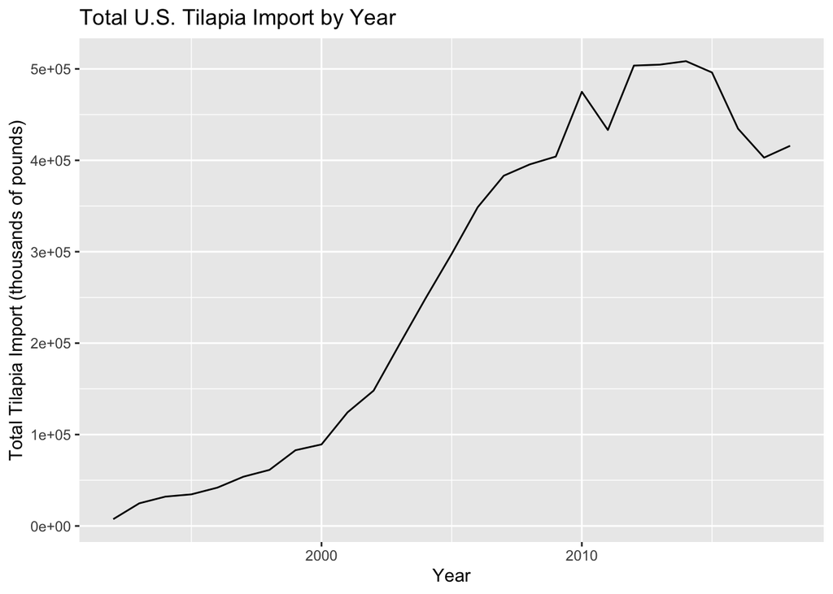

```r
Total_tilapia_import_by_year <- ggplot(data = yearly_tilapia_tot, aes(x = Year, y = total_tilapia_import)) +
  geom_line() +
  labs(
    title = "Total U.S. Tilapia Import by Year"
  ) +
  xlab("Year") +
  ylab("Total Tilapia Import (thousands of pounds)")


Total_tilapia_import_by_year
```

# Create a subset that only retains imports from Ecuador, Honduras, Costa Rica, and Mexico (you decide what to name this)

```r
E_H_CR_M_tilapia_imports <- reshaped_tilapia %>%
  filter(country %in% c("Ecuador", "Honduras", "Costa Rica", "Mexico"))

E_H_CR_M_tilapia_imports
```

```
## # A tibble: 108 × 3
##    country  Year total_tilapia_import
##    <chr>   <dbl>                <dbl>
##  1 Ecuador  1992                   NA
##  2 Ecuador  1993                   22
##  3 Ecuador  1994                   89
##  4 Ecuador  1995                  689
##  5 Ecuador  1996                 2117
##  6 Ecuador  1997                 1942
##  7 Ecuador  1998                 1669
##  8 Ecuador  1999                 4435
##  9 Ecuador  2000                 7600
## 10 Ecuador  2001                11441
## # … with 98 more rows
```

# Create a ggplot graph of total US tilapia imports over time, for those four countries in the subset you created above, separated by country. Update axis labels, add a title, customize your color scheme, update the theme. Export a .jpg of your graph to figs.

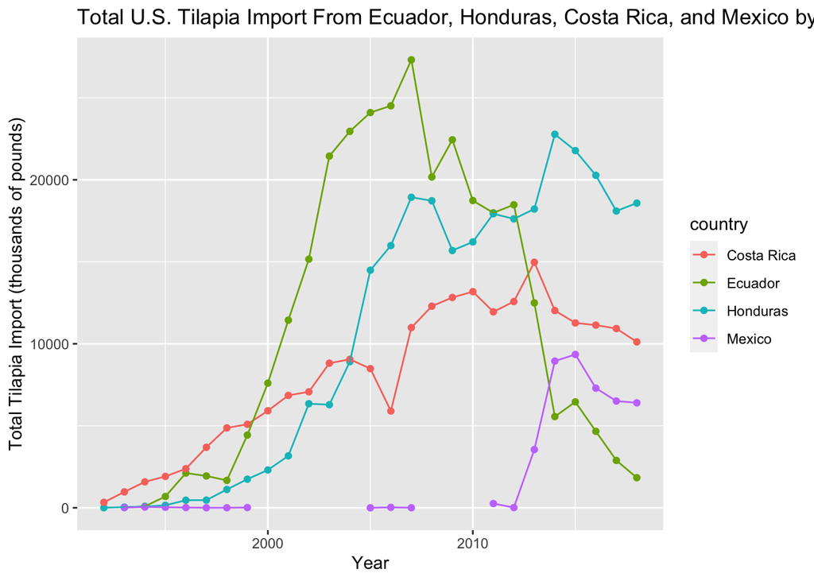

```r
E_H_CR_M_tilapia_graph <- ggplot(data = E_H_CR_M_tilapia_imports, aes(x = Year, y = total_tilapia_import, color = country)) +
  geom_point() +
  geom_line() +
  labs(
    title = "Total U.S. Tilapia Import From Ecuador, Honduras, Costa Rica, and Mexico by Year"
  ) +
  xlab("Year") +
  ylab("Total Tilapia Import (thousands of pounds)")

E_H_CR_M_tilapia_graph
```

```r
ggsave(here("figs", "E_H_CR_M_tilapia_imports.png"), plot = E_H_CR_M_tilapia_graph )
```